# PEC2

UOC

Otoño de 2024

### NOMBRE: [Andrés Rojo Cabrera]

# 1 Objetivos del aprendizaje

El objetivo de esta actividad es que el estudiante se familiarice con conceptos básicos de la inferencia estadística. Específicamente, al terminar la actividad el estudiante debe ser capaz de:

- Distinguir entre los parámetros de una muestra y los parámetros de una población.
- Calcular los intervalos de confianza para la media de una población.
- Realizar contrastes de hipótesis sobre la media de la población.
- Distinguir entre la distribución normal y la distribución t de Student y conocer las condiciones de aplicación de ambas.
- Describir el concepto de correlación.
- Comprender la regresión, específicamente la regresión lineal y saber interpretar y aplicar sus resultados.

En esta PEC seguiremos utilizando el conjunto de datos ‘worlcup’ sobre la copa mundial de fútbol celebrada en Sudáfrica el año 2010.

Recordemos que es una tabla de datos donde las filas representan jugadores y las columnas características de dichos jugadores.

Las variables o características de los jugadores que nos interesan son las siguientes:

1. `Team`: equipo al que pertenece el jugador.
2. `Position`: posición en la que juega el jugador: `Defender` (defensa), `Forward` (delantero), `Goalkeeper` (portero) o `Midfielder` (centrocampista).
3. `Time`: tiempo que ha jugado el jugador en minutos.
4. `Shots`: número de tiros a puerta realizados por el jugador.
5. `Passes`: número de pases realizados por el jugador.
6. `Tackles`: número de entradas realizadas por el jugador.
7. `Saves`: número de paradas realizadas por el jugador.

Importante:

1. Esta PEC debe realizarse de forma estrictamente individual, quedando del todo prohibido el uso de herramientas de IA. Cualquier indicio de copia será penalizado con un suspenso (D) por todas las partes implicadas y la posible evaluación negativa de la asignatura de forma íntegra.
2. Es necesario que el estudiante indique todas las fuentes que ha utilizado para la realización de la PEC. De no ser así, se considerará que el estudiante ha cometido plagio, siendo penalizado con un suspenso (D) y la posible evaluación negativa de la asignatura de manera íntegra.

# 2 Preparar el juego de datos (0.5 puntos)

- Para realizar esta PEC, puedes partir de los objetos `worldcup` y `worldcup.Spain` generados como resultado de la PEC0.
- Si no realizaste la PEC0, bájate la solución y copia todos los pasos realizados.

## Solución

```r
# Para esta práctica, de nuevo, cargamos librería necesaria y seleccionamos el dataset a utilizar y generamos una subtabla con los jugadores de la selección de España.
library(faraway)

# visualizamos qué tipo de datos está compuesta la tabla y vemos las 10 primeras filas
str(worldcup)
```

```
## 'data.frame':    595 obs. of  7 variables:
##  $ Team    : Factor w/ 32 levels "Algeria","Argentina",..: 1 16 9 9 5 32 11 11 18 20 ...
##  $ Position: Factor w/ 4 levels "Defender","Forward",..: 4 4 1 4 2 2 1 2 4 1 ...
##  $ Time    : int  16 351 180 270 46 72 138 33 21 103 ...
##  $ Shots   : int  0 0 0 1 2 0 0 0 5 0 ...
##  $ Passes  : int  6 101 91 111 16 15 51 9 22 38 ...
##  $ Tackles : int  0 14 6 5 0 0 2 0 0 1 ...
##  $ Saves   : int  0 0 0 0 0 0 0 0 0 0 ...
```

```r
head(worldcup, 10)
```

```
##                   Team   Position Time Shots Passes Tackles Saves
## Abdoun         Algeria Midfielder   16     0      6       0     0
## Abe              Japan Midfielder  351     0    101      14     0
## Abidal          France   Defender  180     0     91       6     0
## Abou Diaby      France Midfielder  270     1    111       5     0
## Aboubakar     Cameroon    Forward   46     2     16       0     0
## Abreu          Uruguay    Forward   72     0     15       0     0
## Addy             Ghana   Defender  138     0     51       2     0
## Adiyiah          Ghana    Forward   33     0      9       0     0
## Afellay    Netherlands Midfielder   21     5     22       0     0
## Afolabi        Nigeria   Defender  103     0     38       1     0
```

```r
# generamos la subtabla "worldcup.Spain" y hacemos una copia de seguridad
dfcup = worldcup
worldcup.Spain = dfcup[dfcup$Team == "Spain", ]

# visualizamos los 6 primeros valores de la nueva subtabla generada.
head(worldcup.Spain)
```

```
##            Team   Position Time Shots Passes Tackles Saves
## Alonso    Spain Midfielder  506     9    465      18     0
## Arbeloa   Spain   Defender   13     0     12       0     0
## Busquets  Spain Midfielder  511     0    466      15     0
## Capdevila Spain   Defender  540     1    310      10     0
## Casillas  Spain Goalkeeper  540     0     67       0    11
## Fabregas  Spain Midfielder   94     1    116       2     0
```

```r
# vamos a cambiar el nombre de las columnas del dataset "worldcup" para poder tenerlo más legible y unificado con el enunciado de la PEC2
colnames(dfcup)<-c ("Equipo","Posicion","Tiempo","Tiros","Pases","Entradas","Paradas")
str(dfcup)
```

```
## 'data.frame':    595 obs. of  7 variables:
##  $ Equipo  : Factor w/ 32 levels "Algeria","Argentina",..: 1 16 9 9 5 32 11 11 18 20 ...
##  $ Posicion: Factor w/ 4 levels "Defender","Forward",..: 4 4 1 4 2 2 1 2 4 1 ...
##  $ Tiempo  : int  16 351 180 270 46 72 138 33 21 103 ...
##  $ Tiros   : int  0 0 0 1 2 0 0 0 5 0 ...
##  $ Pases   : int  6 101 91 111 16 15 51 9 22 38 ...
##  $ Entradas: int  0 14 6 5 0 0 2 0 0 1 ...
##  $ Paradas : int  0 0 0 0 0 0 0 0 0 0 ...
```

```r
# a continuación vamos a generar la variable nueva "tiempo_juego" que nos pedian en la PEC0

# creamos una variable donde recoger los valores de las medidas de dispersión de la variable Tiempo
medidas = summary(dfcup$Tiempo)

# visualizamos las medidas de dispersión
medidas
```

```
##    Min. 1st Qu.  Median    Mean 3rd Qu.    Max.
##     1.0    88.0   191.0   208.9   270.0   570.0
```

```r
#creamos la nueva variable "tiempo_juego" con las 5 medidas de dispersión y sus etiquetas dejando de lado la media, que sería la posición 4 "medidas[4]"
dfcup$tiempo_juego = cut(dfcup$Tiempo,
                  breaks=c(medidas[1],medidas[2],medidas[3],medidas[5],medidas[6]), labels=c("Bajo","Medio bajo","Medio alto","Alto"), include.lowest = TRUE)

head(dfcup)
```

```
##              Equipo   Posicion Tiempo Tiros Pases Entradas Paradas tiempo_juego
## Abdoun      Algeria Midfielder     16     0     6        0       0         Bajo
## Abe           Japan Midfielder    351     0   101       14       0         Alto
## Abidal       France   Defender    180     0    91        6       0   Medio bajo
## Abou Diaby   France Midfielder    270     1   111        5       0   Medio alto
## Aboubakar  Cameroon    Forward     46     2    16        0       0         Bajo
## Abreu       Uruguay    Forward     72     0    15        0       0         Bajo
```

```r
# para el resto de ejercicios solo vamos a utilizar el dataset de "dfcup" (la copia de seguridad de worldcup), con todos los equipos del mundial de Sudáfrica del 2010.
```

En toda la PEC vamos a usar la tabla de datos `worldcup`, es decir, los jugadores de todos los países.

# 3 Realizar inferencias (3 puntos)

1. Se ha afirmado que el valor medio del tiempo que juega un jugador vale 190 minutos. Hay sospechas que sugieren que dicho valor medio es superior a 190 minutos.
2. Formula una hipótesis nula y una alternativa apropiadas para evaluar esta afirmación.
3. ¿Cuál es el p-value del test de hipótesis? (nivel de confianza = 95% o $\alpha$ = 0.05). Haz el contraste de hipótesis para calcularlo. ¿Qué conclusiones se pueden sacar?
4. En el contexto de esta situación, describe el error tipo I y el error tipo II.
5. ¿Se ha utilizado la distribución t-Student o la Normal? ¿Por qué?
6. Queremos hallar un intervalo de confianza para la variable tiempo que juega un jugador al 95% de confianza. ¿Cuál es dicho intervalo?

## Solución

```r
# utilizaremos la copia que hicimos en el apartado anterior que ya contiene la columna "tiempo_juego"
head(dfcup)
```

```
##              Equipo   Posicion Tiempo Tiros Pases Entradas Paradas tiempo_juego
## Abdoun      Algeria Midfielder     16     0     6        0       0         Bajo
## Abe           Japan Midfielder    351     0   101       14       0         Alto
## Abidal       France   Defender    180     0    91        6       0   Medio bajo
## Abou Diaby   France Midfielder    270     1   111        5       0   Medio alto
## Aboubakar  Cameroon    Forward     46     2    16        0       0         Bajo
## Abreu       Uruguay    Forward     72     0    15        0       0         Bajo
```

```r
# vamos a empezar con el test de hipótesis y utilizaremos el argumento "t.test"

# según el ejercicio, se afirma que la media de la variable "Tiempo" que juega un jugador se dice que es 190 min, pero se postula que el "Tiempo" es mayor a 190 minutos.
```

La hipótesis nula $H_0$ como dice el enunciado, la media de tiempo que un jugador juega es de 190 minutos. La hipótesis alternativa $H_1$ es, que la media sea mayor a 190 min.

2. Veamos el contraste de Hipótesis:

$$\begin{array}{l}
H_{0}:\mu=190\\
H_{1}:\mu> 190
\end{array}$$

Podemos decir que se trata de un contraste **unilateral** ya que la hipótesis alternativa $H_1$ viene definida por el signo $>$ (mayor que).(1)

```r
# vamos a calcular el p-valor del test de hipótesis con los datos que nos dan, utilizaremos el argumento alternative="greater" pues es un contraste unilatelal y se sospecha que los jugadores puedan jugar más de 190 minutos.

t.test(dfcup$Tiempo, mu = 190, alternative = "greater", conf.level = 0.95)
```

```
##
##  One Sample t-test
##
## data:  dfcup$Tiempo
## t = 3.1639, df = 594, p-value = 0.0008181
## alternative hypothesis: true mean is greater than 190
## 95 percent confidence interval:
##  199.0416      Inf
## sample estimates:
## mean of x
##  208.8639
```

Nivel de confianza, 1- $\alpha$: 0.95

Nivel de significación, $\alpha$: 0.05

3. Nos piden el `p-value` que es: **0.0008181**, un valor muy pequeño, por lo tanto, rechazamos la hipótesis nula $\mu = 190$ con un nivel de significación del **0.05**, y elegimos la hipótesis alternativa, $\mu > 190$, o lo que es lo mismo, con una confianza del 95% podemos afirmar que la media de minutos jugados por un jugador es mayor a 190. Ahora vamos a analizar las demás conclusiones obtenidas del `T-test`.
- La media es $\mu = 208.864$, por lo que es cierto la $H_1$ donde la media es mayor a 190 minutos jugados.
- El estadístico de contraste `t` es **3.164** con `df=594` grados de libertad cuando la hipótesis nula es verdadera.
- El intervalo de confianza `95 percent confidence interval` para la $\mu$ es de:$[199.0416, \infty]$, este valor nos dice que, al no pertenecer $\mu = 190$ a dicho intervalo, sería otro indicador para rechazar la hipótesis nula $H_0$.
4. Habría de destacar un error de `Tipo I` pues esta controlado por el nivel de significancia, esto quiere decir que, al rechazar la hipótesis nula $H_0$, con un `p-value` de **0.0008181** que es un valor mucho menor al nivel de significación del **0.05**, siendo esta verdadera, hay suficientes evidencias de que los jugadores juegan de media más de 190 minutos. No podemos destacar un error de `Tipo II` pues el resultado del `T.test` rechaza la hipótesis nula $H_0$ y el error de `Tipo II` ocurre cuando no rechazamos la $H_0$ por tanto y como se ha comentado antes la media de tiempo de juego de los jugadores es mayor a 190 minutos.
5. Se ha utilizado un `T-student` ya que la distribución es aproximadamente “normal” además desconocemos el valor de $\sigma$ pero sí conocemos uno de sus parámetros, en este caso es la media $\mu$.

```r
# Sabiendo que el enunciado del ejercicio 3 apartado 6 pide intervalo de conficanza para un nivel de confianza de 95%, pero como lo hemos calculado antes, vamos a calcularlo para un nivel de confianza de un 90% y el resultado lo compararemos con el anterior.

t.test(dfcup$Tiempo, mu = 190, alternative = "greater",conf.level = 0.90)
```

```
##
##  One Sample t-test
##
## data:  dfcup$Tiempo
## t = 3.1639, df = 594, p-value = 0.0008181
## alternative hypothesis: true mean is greater than 190
## 90 percent confidence interval:
##  201.2145      Inf
## sample estimates:
## mean of x
##  208.8639
```

6. El intervalo de conficanza para la variable `Tiempo` que juega un jugador al 95% de confianza es $[199.0416, \infty]$, y el intervalo de confianza para un 90% de confianza es $[201.2145, \infty]$.

Podemos observar que el intervalo de confianza se hace más estrecho para confianzas mas pequeñas y observamos que los demás valores no varian, por ende, el nivel de significación aumenta a **0.10**, ocurriendo de igual manera para confianzas de 80% y sucesivamente, estrechándose aún más el intervalo de confianza cada vez que disminuye el nivel de confianza.

# 4 Análisis de correlaciones (3 puntos)

1. Calcula la correlación lineal de la variable `Tiempo` con las variables `Pases` y `Tiros`. Interpreta el resultado de ambos coeficientes de correlación. A la vista de los resultados, ¿con cuál de las variables se relaciona más?
2. ¿Qué hubiese pasado si el signo de la correlación entre la variable `Tiempo` y `Pases` fuera negativo?
3. Haz un gráfico de dispersión entre la variable `Tiempo` y la variable más relacionada con ella (de las dos utilizadas anteriormente).

## Solución

```r
# vamos a correlacionar variables, vamos a hacer la correlación con la función "cor" de la variable dependiente "Tiempo" con otras dos independientes, en este caso, "Pases" y "Tiros".

# primera correlación entre "Tiempo" y "Pases", vamos a utilizar el argumento "complete.obs", pues en el caso de tener valores NA (que no es el caso en ninguna de las variables), se eliminasen y realice la correlación sin problemas.
cor(dfcup$Tiempo, dfcup$Pases, use="complete.obs")
```

```
## [1] 0.8151193
```

```r
# ahora la correlación entre la variable "Tiempo" y "Tiros".
cor(dfcup$Tiempo, dfcup$Tiros, use ="complete.obs")
```

```
## [1] 0.4079231
```

1. Podemos observar que la variable `Tiempo` tiene más correlación con la variable `Pases` con **0.8151** que con `Tiros`, siendo **0.4079** el resultado de la correlación, es decir, en la relación lineal, la variable `Pases` se ajusta mejor que con la variable `Tiros`.
2. Si hubiese sido una correlación negativa, sería una relación inversa, es decir, si una crece la otra decrece o viceversa, pero al ser una corrlación positiva significa que una crece y la otra también.

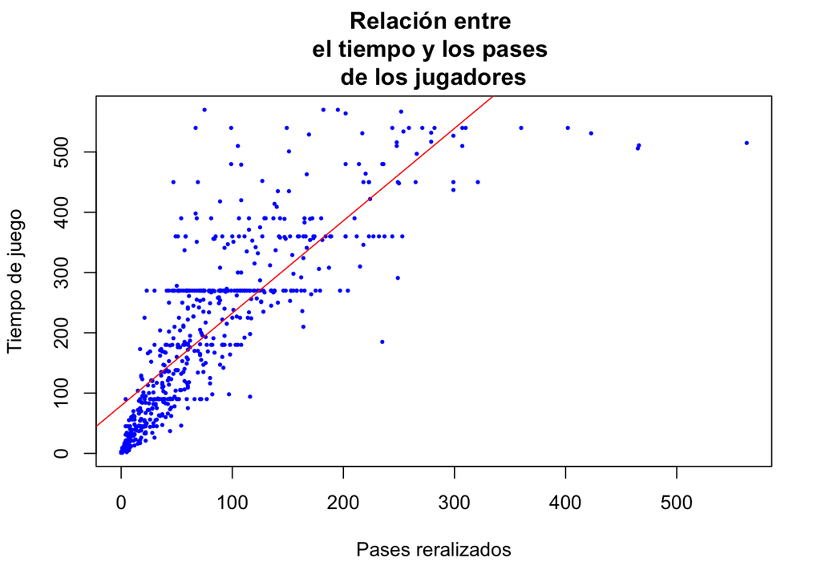

```r
# vamos a graficar la relación entre las dos variables anteriormente mencionadas
plot(dfcup$Pases, dfcup$Tiempo, pch= 20, col="blue",cex = 0.5, main = "Relación entre \nel tiempo y los pases \nde los jugadores", xlab = "Pases reralizados", ylab = "Tiempo de juego")

# vamos a hacer una regresión lineal de la variable idependiente "Tiempo" en función de la variable independiente "Pases" y lo asignamos en la variable "modelo1".
modelo1<-lm(Tiempo~Pases, data=dfcup)

# con "abline" dibujamos la linea que muestra la relación entre los valores de la variables
abline(modelo1, col="red")
```

3. Nos podemos hacer una idea de cómo es el modelo de efectivo simplemente observando la gran dispersión de los valores, por lo tanto, la líne a de regresión no se ajusta del todo bien a los puntos de la muestra. Podemos asegurar que el $R^2$ no nos va a dar un valor cercano al 1, y por tanto, deducimos que no es un buen modelo.

# 5 Regresión lineal (3.5 puntos)

1. Queremos saber las variables qué mas influyen en el tiempo de juego de los jugadores. Para ello, hemos realizado una regresión lineal múltiple de la variable `Tiempo` en función de las demás excepto las variables `Equipo` y la nueva introducida en la PEC0 `tiempo_juego`.
2. Escribe la ecuación de regresión.
3. ¿Cual será la predicción del tiempo de juego de Messi?
4. ¿Cuál es el valor del coeficiente de determinación? ¿Se ajusta bien el modelo?
5. Interpreta los diferentes parámetros de la regresión, es decir el intercepto y los diferentes coeficientes o predictores.
6. ¿Puede eliminarse alguna variable/predictor del modelo a un nivel de significación del 10%? Razona la respuesta, propón un nuevo modelo con la variable o variables eliminadas y compáralo con el modelo anterior.

## Solución

```r
# vamos a hacer una regresión lineal multiple sin las variables "Equipo" y "tiempo_juego"
head(dfcup)
```

```
##              Equipo   Posicion Tiempo Tiros Pases Entradas Paradas tiempo_juego
## Abdoun      Algeria Midfielder     16     0     6        0       0         Bajo
## Abe           Japan Midfielder    351     0   101       14       0         Alto
## Abidal       France   Defender    180     0    91        6       0   Medio bajo
## Abou Diaby   France Midfielder    270     1   111        5       0   Medio alto
## Aboubakar  Cameroon    Forward     46     2    16        0       0         Bajo
## Abreu       Uruguay    Forward     72     0    15        0       0         Bajo
```

```r
regre.juego<-lm(Tiempo~. -Equipo -tiempo_juego, data = dfcup)

# visualizamos los coeficientes del modelo "regre.juego"
regre.juego
```

```
##
## Call:
## lm(formula = Tiempo ~ . - Equipo - tiempo_juego, data = dfcup)
##
## Coefficients:
##        (Intercept)     PosicionForward  PosicionGoalkeeper  PosicionMidfielder
##             75.612             -24.449              44.763             -52.458
##              Tiros               Pases            Entradas             Paradas
##             10.424               1.129               6.944              11.899
```

De esta ecuación tan larga podemos comprobar que según la posición del jugador se multiplica el porcentaje de la posición del jugador por el coeficiente 1, pero si el jugador no es, por ejemplo, “delantero”, el porcentaje se multiplicará por el coeficiente 0, anulando dicha posición.

Otra cosa a destacar es que la posición “defensa” desaparece en la ecuación y por tanto en el `summary` , “resumen” de los valores del modelo, pues dicha posición no parece explicitamente en el modelo, pero su efecto está incluido en el intercepto.(2)

```r
# vamos a generar una subtabla con el jugador Messi y sus variables
Messi<-dfcup[rownames(dfcup)== "Messi", ]
# lo visualizamos
Messi
```

```
##          Equipo Posicion Tiempo Tiros Pases Entradas Paradas tiempo_juego
## Messi Argentina  Forward    450    21   321       10       0         Alto
```

```r
# ahora vamos a predecir el tiempo de la subtabla con los datos de Messi
predict(regre.juego, newdata=Messi, interval="confidence")
```

```
##            fit      lwr      upr
## Messi 702.0368 672.2672 731.8064
```

3. El resultado arrojado por la función `predict` es **702.0369** para el delantero “Messi” y además el intervalo calculado para el valor de la variable dependiente es $[672.267,731.806]$

```r
# vamos a ver cual es es valor del coeficiente de determinación. Para ello utilizamos con la función "summary" y filtramos con "$r.squared" al final de la operación

summary(regre.juego)$r.squared
```

```
## [1] 0.8200036
```

4. El resultado obtenido del confidente de determinación o lo que es lo mismo el valor de $R^2$ es **0.8200036**, lo cual significa que está bien ajustado pero podría estar mejor.

```r
# observemos los valores de los coeficientes del modelo con la función "summary" de nuestro modelo "regre.juego" y el filtro "$coefficients"
summary(regre.juego)$coefficients
```

```
##                      Estimate  Std. Error   t value     Pr(>|t|)
## (Intercept)         75.612419  5.89170084 12.833717 2.089289e-33
## PosicionForward    -24.449063  8.10368815 -3.017029 2.663220e-03
## PosicionGoalkeeper  44.763320 23.95163379  1.868905 6.213387e-02
## PosicionMidfielder -52.458271  6.25196854 -8.390681 3.615710e-16
## Tiros               10.424033  0.93139236 11.191882 1.728409e-26
## Pases                1.129373  0.05091728 22.180547 1.239768e-79
## Entradas             6.944003  0.80429626  8.633638 5.597805e-17
## Paradas             11.899172  1.89667138  6.273713 6.846803e-10
```

5. El **intercepto** es el valor en el que la línea resultante corta al eje ordenadas, en este caso, $\beta_0 = 75.612$. Además vemos que las variables independienes `Tiros`,`Pases`,`Entradas` y `Paradas` son muy significativas y aumentan el porcentaje la variable `Tiempo` pero la la variable `Posicion` pese a ser relativamente significativa, le resta porcentaje de tiempo a los jugadores en las posiciones de “Delantero” y “Mediocampo”.

```r
# vamos a comprobar con un nivel de significación del 10% qué variable podríamos eliminar para así plantear un nuevo modelo.

summary(regre.juego)
```

```
##
## Call:
## lm(formula = Tiempo ~ . - Equipo - tiempo_juego, data = dfcup)
##
## Residuals:
##     Min      1Q  Median      3Q     Max
## -261.12  -39.66   -8.12   36.11  213.06
##
## Coefficients:
##                     Estimate Std. Error t value Pr(>|t|)
## (Intercept)         75.61242    5.89170  12.834  < 2e-16 ***
## PosicionForward    -24.44906    8.10369  -3.017  0.00266 **
## PosicionGoalkeeper  44.76332   23.95163   1.869  0.06213 .
## PosicionMidfielder -52.45827    6.25197  -8.391 3.62e-16 ***
## Tiros               10.42403    0.93139  11.192  < 2e-16 ***
## Pases                1.12937    0.05092  22.181  < 2e-16 ***
## Entradas             6.94400    0.80430   8.634  < 2e-16 ***
## Paradas             11.89917    1.89667   6.274 6.85e-10 ***
## ---
## Signif. codes:  0 '***' 0.001 '**' 0.01 '*' 0.05 '.' 0.1 ' ' 1
##
## Residual standard error: 62.07 on 587 degrees of freedom
## Multiple R-squared:   0.82,  Adjusted R-squared:  0.8179
## F-statistic:   382 on 7 and 587 DF,  p-value: < 2.2e-16
```

6. Para un nivel de significacio del 10%, es decir, $\alpha = 0.10$, por lo tanto, si hubiera alguna variable independiente con el `p-value` superior, podríamos eliminarla para generar un nuevo y mejorado modelo. Ahora, por ejemplo,si la variable `Posicion` que es la variable que puede tener algo menos de significancia con la variable dependiente `Tiempo` la eliminamos del modelo nos da un $R^2$ menor, vamos a comprobarlo cogiendo en modelo base y quitando dicha variable.

```r
# vamos a actualizar el actual modelo que estamos viendo y le vamos a quitar la variable independiente "Posicion"
nuevo.modelo<-update(regre.juego, .~.-Posicion)

# seleccionamos el coeficiente de determinación para ver qué tan bueno es el modelo prediciendo
summary(nuevo.modelo)$r.squared
```

```
## [1] 0.7950295
```

Como podemos comprobar, en esta actualización del modelo, que el coeficiente de determinación $R^2 = 0.7950295$ se aleja de 1 más que el modelo base `regre.juego` por lo que no sería muy adecuado eliminar la variable `Posicion` pero si queremos buscar un modelo más ajustado deberíamos dejar la variable `tiempo_juego` que se elimina al inicio del ejercicio.

```r
# vamos a añadir por curiosidad la variable "tiempo de juego" al primer modelo ya existente
add.modelo<-update(regre.juego, .~.+tiempo_juego)

# comprobamos su coeficiente de determinación y el coeficiente ajustado
summary(add.modelo)$r.squared
```

```
## [1] 0.9361845
```

```r
summary(add.modelo)$adj.r.squared
```

```
## [1] 0.9350917
```

Siendo ahora $R^2 = 0.9361845$ el valor mas alto para este nuevo modelo actualizado y por lo tanto este modelo va a ser mejor a la hora de predecir que el modelo base.

```r
# cargamos la subtabla "Messi"
Messi
```

```
##          Equipo Posicion Tiempo Tiros Pases Entradas Paradas tiempo_juego
## Messi Argentina  Forward    450    21   321       10       0         Alto
```

```r
# vamos a predecir el nuevo resultado de Messi con el modelo actualizado
predict(add.modelo, Messi, interval="confidence")
```

```
##            fit      lwr      upr
## Messi 529.8018 509.1237 550.4799
```

Para concluir, el valor que nos dio el predictor con el modelo base `regre.juego` fue **702.0368**, un valor un poco alto y con este nuevo modelo, `add.modelo` nos arroja un valor ajustado de **529.8018** algo más coherente para el Tiempo de juego del jugador Messi.

# 6 Referencias Bibliográficas

1.

team TUA. Lección 5 contrastes de hipótesis | AprendeR: Parte II [Internet]. 2021. Available from: https://aprender-uib.github.io/AprendeR2/chap-contrastes.html

2.

team TUA. Lección 10 regresión lineal | AprendeR: Parte II [Internet]. 2021. Available from: https://aprender-uib.github.io/AprendeR2/chap-regresion.html